# CaseStudy1

Shelby Provost

6/24/2021

Given the Beers data set, containing information of 2410 US craft beers, and the Breweries data set, containing 558 US breweries, an exploratory data analysis (EDA) was performed to extract potential insights from the data.

The first step of the analysis is to import and merge the breweries data with the beers data.

```
##   Brewery_id        Name.x Beer_ID   ABV IBU
## 1          1  Get Together    2692 0.045  50
## 2          1 Maggie's Leap    2691 0.049  26
## 3          1    Wall's End    2690 0.048  19
## 4          1       Pumpion    2689 0.060  38
## 5          1    Stronghold    2688 0.060  25
## 6          1   Parapet ESB    2687 0.056  47
##                                 Style Ounces             Name.y        City
## 1                        American IPA     16 NorthGate Brewing  Minneapolis
## 2                  Milk / Sweet Stout     16 NorthGate Brewing  Minneapolis
## 3                   English Brown Ale     16 NorthGate Brewing  Minneapolis
## 4                         Pumpkin Ale     16 NorthGate Brewing  Minneapolis
## 5                     American Porter     16 NorthGate Brewing  Minneapolis
## 6 Extra Special / Strong Bitter (ESB)     16 NorthGate Brewing  Minneapolis
##   State
## 1    MN
## 2    MN
## 3    MN
## 4    MN
## 5    MN
## 6    MN
```

```
##      Brewery_id                    Name.x Beer_ID   ABV IBU
## 2405        556             Pilsner Ukiah      98 0.055  NA
## 2406        557  Heinnieweisse Weissebier      52 0.049  NA
## 2407        557           Snapperhead IPA      51 0.068  NA
## 2408        557         Moo Thunder Stout      50 0.049  NA
## 2409        557         Porkslap Pale Ale      49 0.043  NA
## 2410        558 Urban Wilderness Pale Ale      30 0.049  NA
##                        Style Ounces                        Name.y          City
## 2405         German Pilsener     12         Ukiah Brewing Company         Ukiah
## 2406              Hefeweizen     12       Butternuts Beer and Ale Garrattsville
## 2407            American IPA     12       Butternuts Beer and Ale Garrattsville
## 2408      Milk / Sweet Stout     12       Butternuts Beer and Ale Garrattsville
## 2409 American Pale Ale (APA)     12       Butternuts Beer and Ale Garrattsville
## 2410        English Pale Ale     12 Sleeping Lady Brewing Company     Anchorage
##      State
## 2405    CA
## 2406    NY
## 2407    NY
## 2408    NY
## 2409    NY
## 2410    AK
```

Then a visual representation of the number of breweries in each state is created with a bar chart ordered from most to least number of breweries. The top 5 and bottom 5 states are extracted from the ordered data as well.

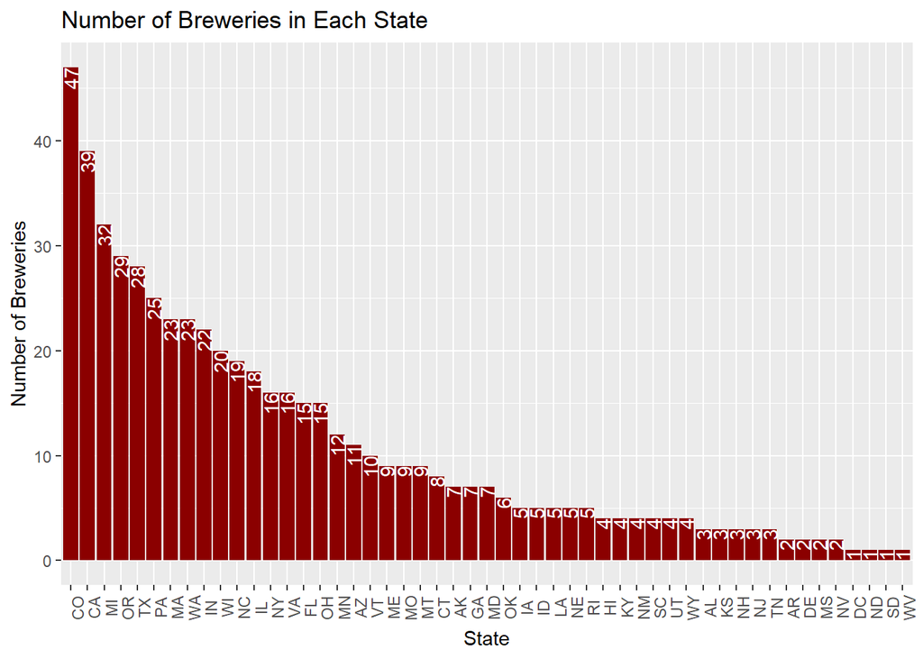

```
## # A tibble: 5 x 2
##   State count
##   <chr> <int>
## 1 " DC"     1
## 2 " ND"     1
## 3 " SD"     1
## 4 " WV"     1
## 5 " AR"     2
```

```
## # A tibble: 5 x 2
##   State count
##   <chr> <int>
## 1 " TX"    28
## 2 " OR"    29
## 3 " MI"    32
## 4 " CA"    39
## 5 " CO"    47
```

```
## [1] 0.08422939
```

The states with the most breweries are Colorado, California, Michigan, Oregon, and Texas. With 47 breweries, Colorado is home to 8.4% of the breweries. The states with the least breweries are District of Columbia, North Dakota, South Dakota, and West Virginia.

[interactive chart not shown]

To perform additional analysis, the merged data is checked for NA’s.

```
## [1] ""
## [1] ""
## [1] ""
## [1] "Has NA"
## [1] "Has NA"
## [1] ""
## [1] ""
## [1] ""
## [1] ""
## [1] ""
```

```
##            sapply.BeersAndBrews..function.x...
## Brewery_id
## Name.x
## Beer_ID
## ABV                                     Has NA
## IBU                                     Has NA
## Style
## Ounces
## Name.y
## City
## State
```

```
##    Mode   FALSE    TRUE
## logical    2348      62
```

```
##    Mode   FALSE    TRUE
## logical    1405    1005
```

The ABV variable has 62 NA values and the IBU variable has 1005 NA values. The NA’s will stay in the merged data set, however they will be filtered out when necessary throughout the analysis.

The median ABV and IBU by state are computed and visually represented with the NA values removed.

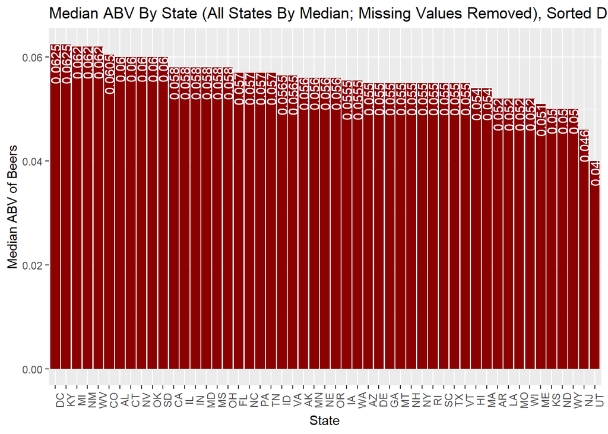

```
##   Med_ABV_All
## 1       0.056
```

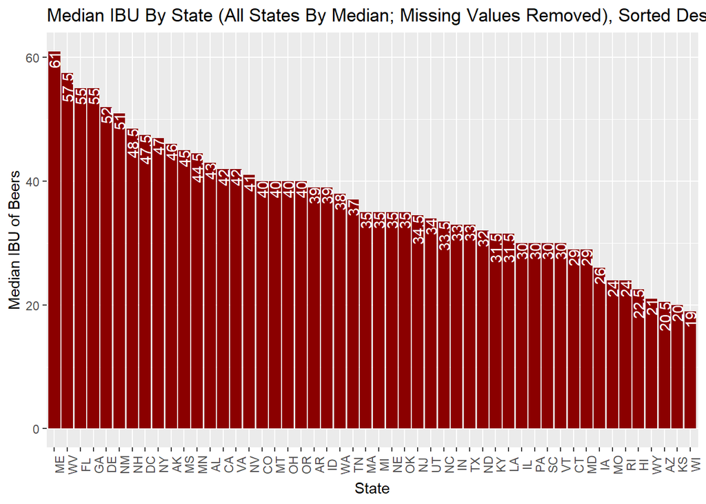

```
##   Med_IBU_All
## 1          35
```

The states with the highest ABV and the highest IBU are extracted.

```
## [1] "State with the maximum alcoholic beer:  CO, Lee Hill Series Vol. 5 - Belgian Style Quadrupel Ale from Upslope Brewing Company, with an alcohol percentage of 12.8%"
```

```
## [1] "State with the maximum bitterness:  OR, Bitter Bitch Imperial IPA from Astoria Brewing Company with an IBU of 138"
```

The distribution of the alcoholic content is examined further.

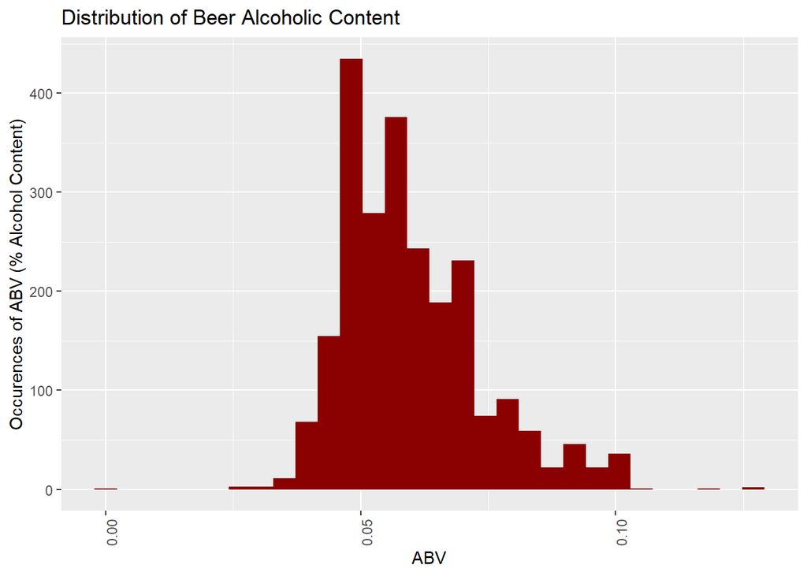

The distribution of the alcoholic content appears to be slightly right skewed. There also is evidence of an outlier.

The distribution of the international bitterness is examined further.

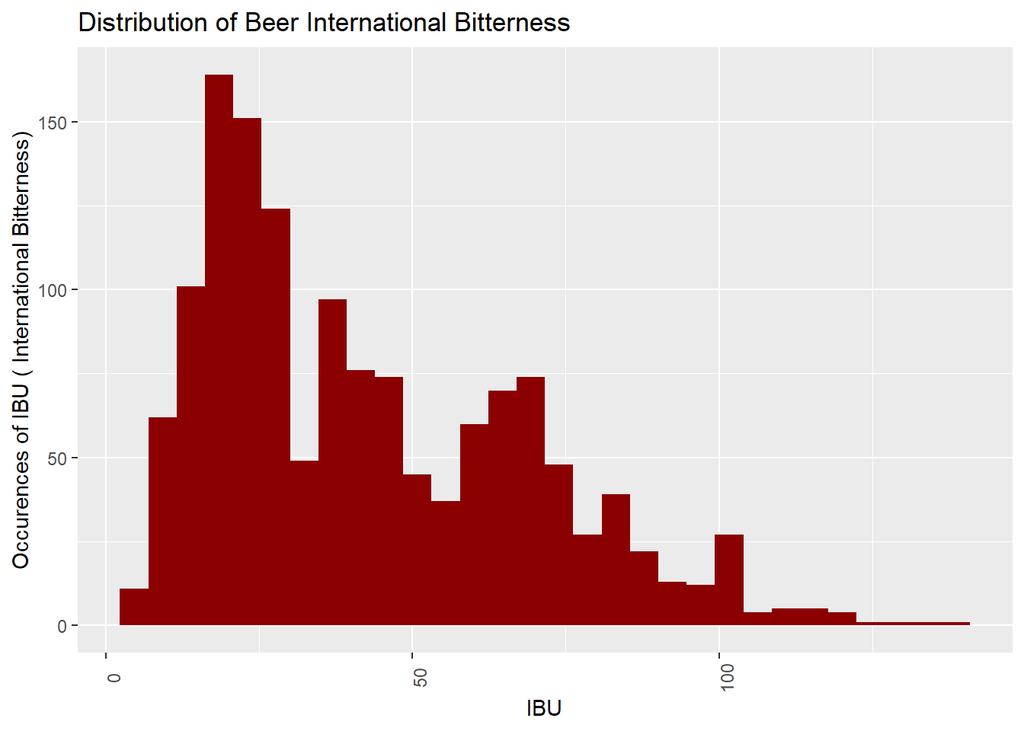

The distribution of the international bitterness appears to be right skewed.

Then, ABV and IBU are assessed for a relationship.

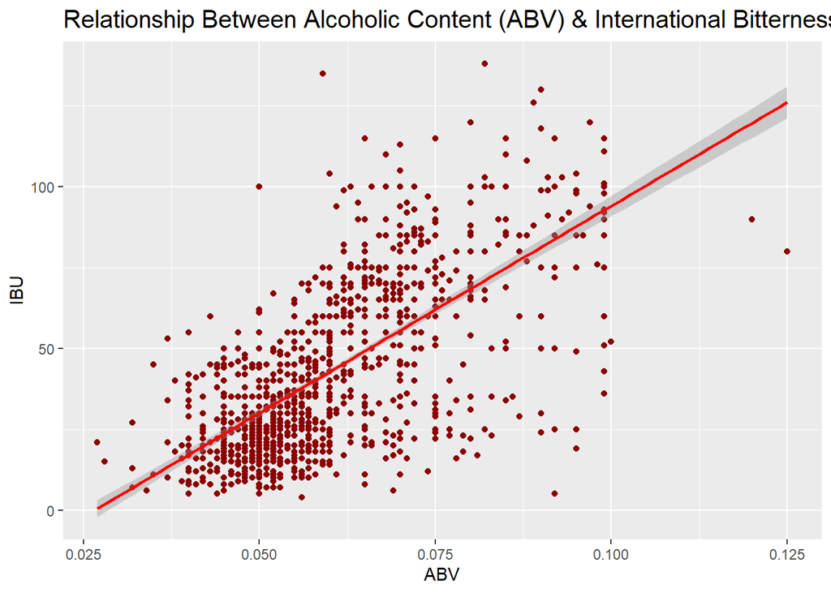

```
##
## Call:
## lm(formula = IBU ~ ABV, data = BeersAndBrews)
##
## Residuals:
##     Min      1Q  Median      3Q     Max
## -78.849 -11.977  -0.721  13.997  93.458
##
## Coefficients:
##             Estimate Std. Error t value Pr(>|t|)
## (Intercept)  -34.099      2.326  -14.66   <2e-16 ***
## ABV         1282.037     37.860   33.86   <2e-16 ***
## ---
## Signif. codes:  0 '***' 0.001 '**' 0.01 '*' 0.05 '.' 0.1 ' ' 1
##
## Residual standard error: 19.26 on 1403 degrees of freedom
##   (1005 observations deleted due to missingness)
## Multiple R-squared:  0.4497, Adjusted R-squared:  0.4493
## F-statistic:  1147 on 1 and 1403 DF,  p-value: < 2.2e-16
```

There is evidence of a linear relationship between ABV and IBU. This can be seen by the regression line showing a positive trend in the data.The higher the ABV, the larger the residuals appear to be, however this is not evidence against the trend since it is likely due to a smaller amount of data points in that range. A test was performed concluding that this visual relationship is significant. It provided a linear regression estimate of: IBU = -34.1 + 1282.037(ABV).

Style flags are used to prepare the data for machine learning.

```
##
##                                                        Abbey Single Ale
##                                   5                                   2
##                             Altbier              American Adjunct Lager
##                                  13                                  18
##            American Amber / Red Ale          American Amber / Red Lager
##                                 133                                  29
##                 American Barleywine                  American Black Ale
##                                   3                                  36
##                 American Blonde Ale                  American Brown Ale
##                                 108                                  70
##             American Dark Wheat Ale      American Double / Imperial IPA
##                                   7                                 105
##  American Double / Imperial Pilsner    American Double / Imperial Stout
##                                   2                                   9
##           American India Pale Lager                        American IPA
##                                   3                                 424
##                American Malt Liquor             American Pale Ale (APA)
##                                   1                                 245
##                 American Pale Lager             American Pale Wheat Ale
##                                  39                                  97
##                    American Pilsner                     American Porter
##                                  25                                  68
##                      American Stout                 American Strong Ale
##                                  39                                  14
##                  American White IPA                   American Wild Ale
##                                  11                                   6
##                       Baltic Porter                    Belgian Dark Ale
##                                   6                                  11
##                         Belgian IPA                    Belgian Pale Ale
##                                  18                                  24
##             Belgian Strong Dark Ale             Belgian Strong Pale Ale
##                                   6                                   7
##                  Berliner Weissbier                     BiÃ¨re de Garde
##                                  11                                   7
##                                Bock                             Braggot
##                                   7                                   1
##      California Common / Steam Beer                          Chile Beer
##                                   6                                   3
##                               Cider                           Cream Ale
```

[output cut: 46 more lines]

```
##                                   3                                   2
##                          Roggenbier              Russian Imperial Stout
##                                   2                                  11
##                            Rye Beer              Saison / Farmhouse Ale
##                                  18                                  52
##                         Schwarzbier              Scotch Ale / Wee Heavy
##                                   9                                  15
##                        Scottish Ale                              Shandy
##                                  19                                   3
##                         Smoked Beer                              Tripel
##                                   1                                  11
##                        Vienna Lager                           Wheat Ale
##                                  20                                   1
##                       Winter Warmer                             Witbier
##                                  15                                  51
```

KNN classification is used to investigate the relationship of ABV and IBU between India Pale Ales (IPA) and all other types of Ales.

The training data set contains 80% of the data, while the test data set contains the remaining 20%.

KNN classifications of IPA’s

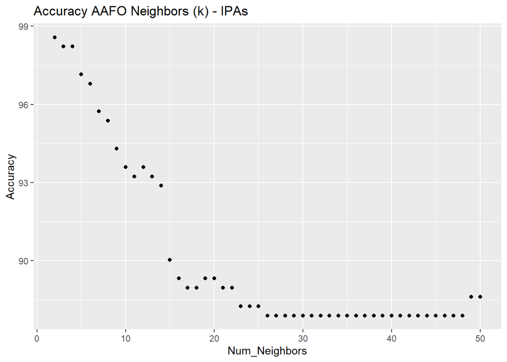

```
## [1] "Confusion Matrix of Ale Classification"
```

```
## Confusion Matrix and Statistics
##
##
## knn_model_Ales   0   1
##              0 201   1
##              1   2  77
##
##                Accuracy : 0.9893
##                  95% CI : (0.9691, 0.9978)
##     No Information Rate : 0.7224
##     P-Value [Acc > NIR] : <2e-16
##
##                   Kappa : 0.9735
##
##  Mcnemar's Test P-Value : 1
##
##             Sensitivity : 0.9901
##             Specificity : 0.9872
##          Pos Pred Value : 0.9950
##          Neg Pred Value : 0.9747
##              Prevalence : 0.7224
##          Detection Rate : 0.7153
##    Detection Prevalence : 0.7189
##       Balanced Accuracy : 0.9887
##
##        'Positive' Class : 0
##
```

This model is 98.93% accurate in predicting whether a beer is an IPA using ABV and IBU.We are 95% confident that the true accuracy is between 96.91% and 99.78%.

KNN classification of all other Ales.

[figure not shown]

```
## [1] "Confusion Matrix of Ale Classification"
```

```
## Confusion Matrix and Statistics
##
##
## knn_model_Ales   0   1
##              0 165   3
##              1   0 113
##
##                Accuracy : 0.9893
##                  95% CI : (0.9691, 0.9978)
##     No Information Rate : 0.5872
##     P-Value [Acc > NIR] : <2e-16
##
##                   Kappa : 0.9779
##
##  Mcnemar's Test P-Value : 0.2482
##
##             Sensitivity : 1.0000
##             Specificity : 0.9741
##          Pos Pred Value : 0.9821
##          Neg Pred Value : 1.0000
##              Prevalence : 0.5872
##          Detection Rate : 0.5872
##    Detection Prevalence : 0.5979
##       Balanced Accuracy : 0.9871
##
##        'Positive' Class : 0
##
```

This model is 98.93% accurate in predicting whether a beer is an Ale other than IPA using ABV and IBU.We are 95% confident that the true accuracy is between 96.91% and 99.78%.

A basic Machine Learning pipeline is used for IBU predictions of the data with missing values for IBU.  
A “No Skill” prediction is leveraged as a baseline, then linear regression, random forest and XGBoost are tested. The accuracy on all test sets are then aggregated (via RMSE).

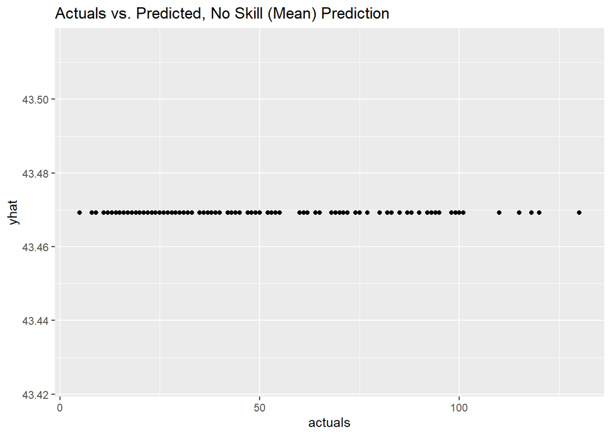

```
##
## Call:
## lm(formula = f, data = train)
##
## Residuals:
##     Min      1Q  Median      3Q     Max
## -49.418  -7.917  -1.180   6.201  73.415
##
## Coefficients:
##             Estimate Std. Error t value Pr(>|t|)
## (Intercept)  -15.007      2.496  -6.012 2.48e-09 ***
## ABV          706.349     41.354  17.080  < 2e-16 ***
## IPA           13.029      5.235   2.489 0.012954 *
## Stout          8.602      2.282   3.770 0.000172 ***
## APA           13.538      1.887   7.174 1.33e-12 ***
## Porter        -2.275      2.539  -0.896 0.370527
## Lager         -2.044      1.895  -1.079 0.280976
## Blonde        -5.788      2.401  -2.410 0.016094 *
## RedAle         4.021      2.090   1.924 0.054607 .
## BlackAle      24.580      3.553   6.919 7.68e-12 ***
## WheatAle      -5.170      2.446  -2.113 0.034813 *
## American       6.657      1.439   4.626 4.17e-06 ***
## English        4.500      2.490   1.807 0.070997 .
## top_states     0.584      2.061   0.283 0.776944
## ABV:IPA      264.270     76.123   3.472 0.000537 ***
## ---
## Signif. codes:  0 '***' 0.001 '**' 0.01 '*' 0.05 '.' 0.1 ' ' 1
##
## Residual standard error: 13.58 on 1109 degrees of freedom
## Multiple R-squared:  0.7264, Adjusted R-squared:  0.723
## F-statistic: 210.3 on 14 and 1109 DF,  p-value: < 2.2e-16
```

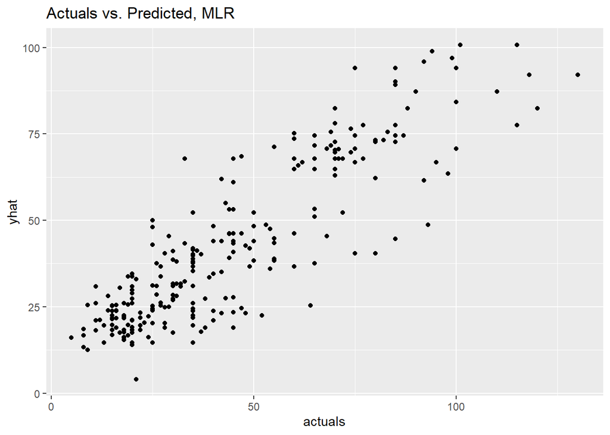

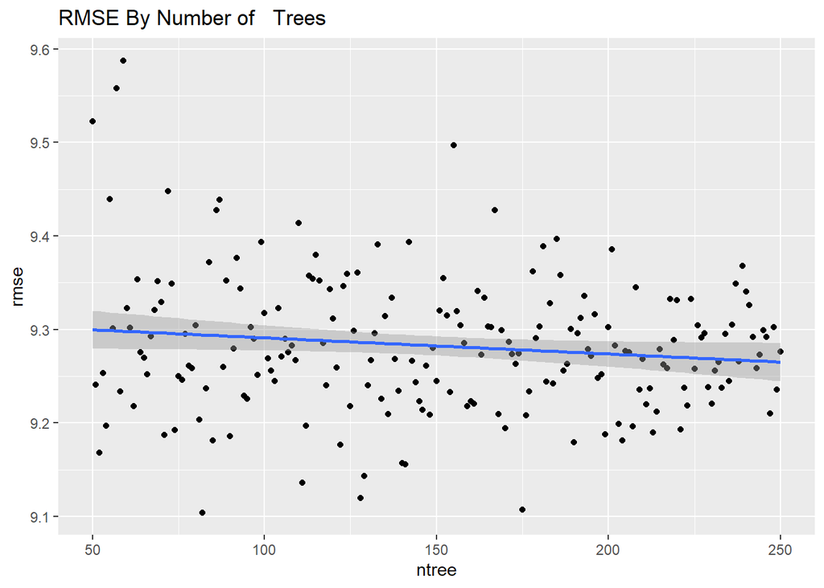

```
##    user  system elapsed
##   36.49    2.18   38.84
```

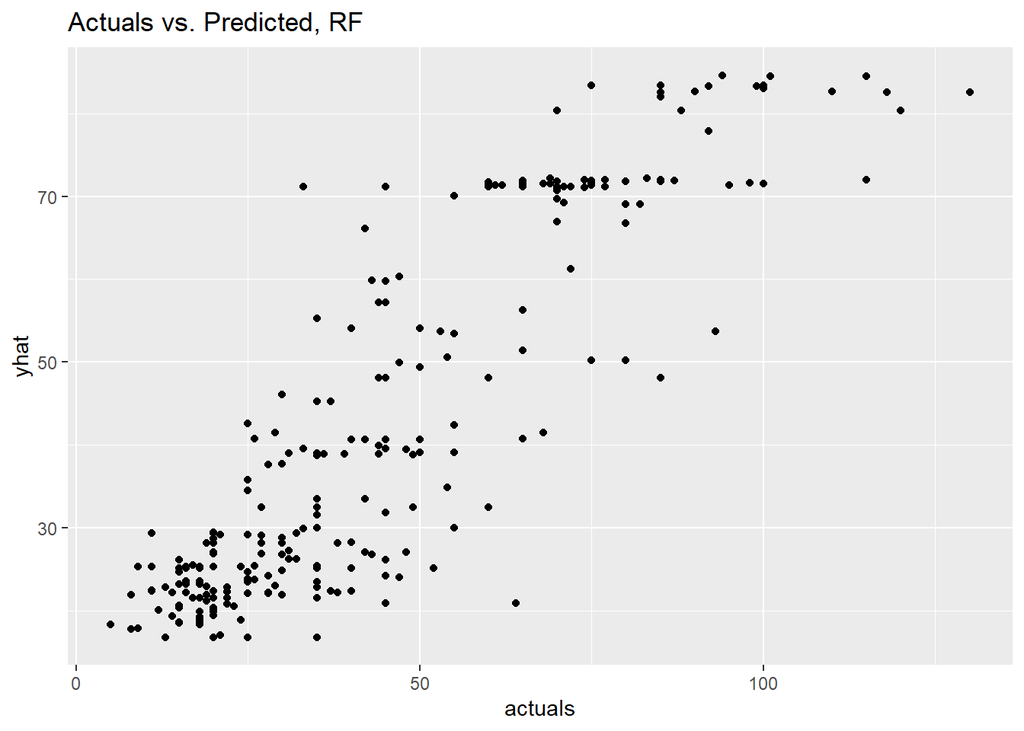

[output not shown]

```
## Fit MSE = 187.1819
## Fit percent variance explained = 72.3
## Median permuted MSE = 5.389412
## Median permuted percent variance explained = 99.205
## Median cross-validation RMSE = 3.697813
## Median cross-validation MBE = 0.2725954
## Median cross-validation MAE = 2.066643
## Range of ks p-values = 0.01652128 0.2699997
## Range of ks D statistic = 0.05 0.07494145
## RMSE cross-validation error variance = 0.3595239
## MBE cross-validation error variance = 0.07097777
## MAE cross-validation error variance = 0.05892349
```

```
## [12:28:42] INFO: amalgamation/../src/tree/updater_prune.cc:101: tree pruning end, 40 extra nodes, 0 pruned nodes, max_depth=8
## [12:28:42] INFO: amalgamation/../src/tree/updater_prune.cc:101: tree pruning end, 502 extra nodes, 0 pruned nodes, max_depth=24
```

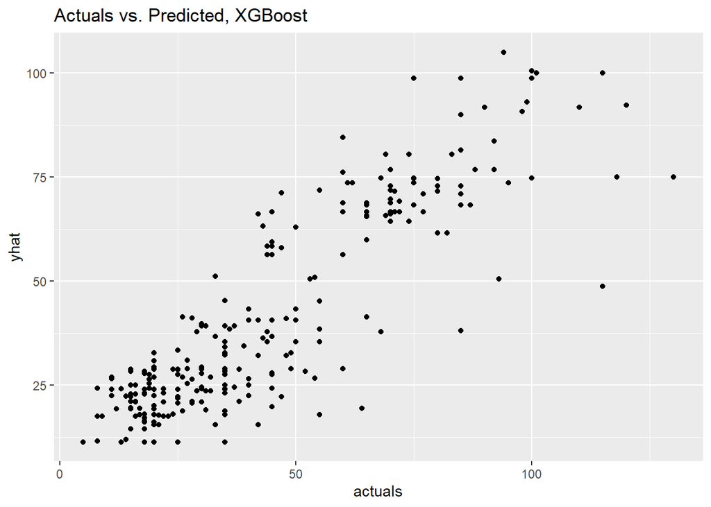

The RMSE accuracy on the models are finalized.

```
##    xg_rmse  rf_rmse  lm_rmse noskill_rmse
## 1 9.214933 9.197549 9.411602     21.93078
```

The optimal model, random forest, is used to predict all NA’s in the original IBU data.

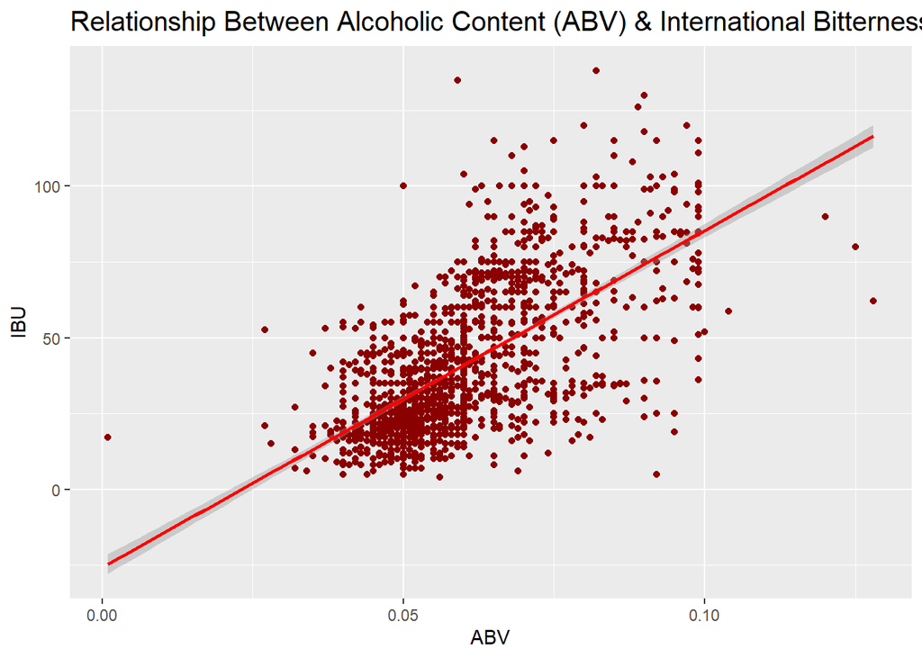

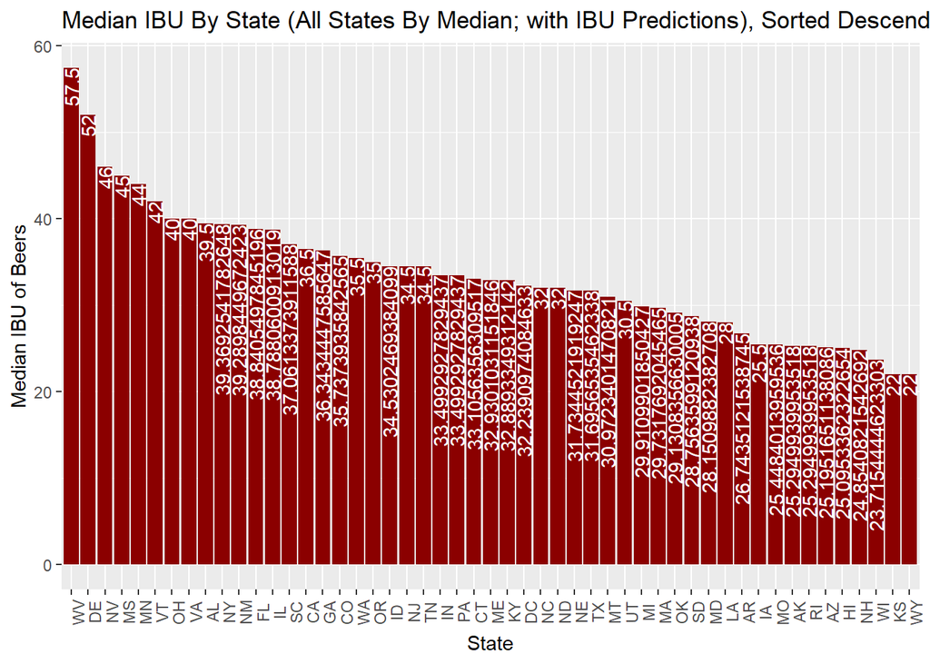

After performing an exploratory data analysis, interest regarding the missing IBU values led to a machine learning pipeline. While 3 models were tested, the random forest model is the most optimal. The model was used to estimate these missing values and were plotted along with the original data.